# Exploratory analysis of TB cases in Dekalb County

### Summary

There were 2522 TB cases in Dekalb Country between January 03, 2006 and June 16, 2017. While cases were reported throughout the county, the highest concentration of cases appears to be clustered near Clarkston. Among those with TB, 59% were male and 41.5% were of Asian descent. In total 80.1% of TB patients were from non-US countries, most commonly Bhutan, Burma, Ethiopia, Nepal, and Thailand. Detailed results are presented below.

#### Tables

Table 1. TB Cases by Gender  
Table 2. TB Cases by Race  
Table 3. TB Cases by Ethnicity  
Table 4. TB Cases by HIV status  
Table 5. TB Cases by Homeless Status  
Table 6. TB Cases by Correctional Facility Status  
Table 7. TB Cases by Alcohol Use  
Table 8. TB Cases by Long Term Facility  
Table 9. TB Cases by Occupation  
Table 10. TB Cases by Country of Origin

#### Maps

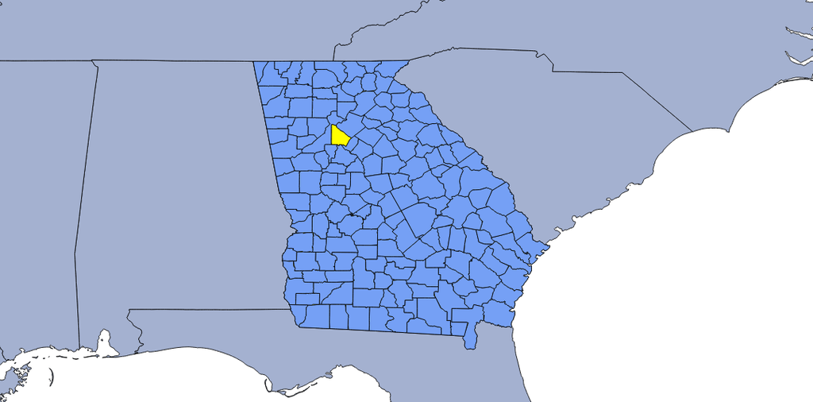

#### Table 1. TB Cases by Gender

|  | Count | Percent |
| --- | --- | --- |
| MALE | 1489 | 59.0% |
| FEMALE | 1006 | 39.9% |
| UNKNOWN | 24 | 1.0% |
| OTHER | 3 | 0.1% |

#### Table 2. TB Cases by Race

|  | Count |
| --- | --- |
| Asian | 1047 |
| Black / African American | 767 |
| Other / Unknown | 479 |
| White | 224 |
| American Indian / Alaska Native | 5 |

#### Table 3. TB Cases by Ethnicity

|  | Count |
| --- | --- |
| NON-HISPANIC | 2029 |
| UNKNOWN | 314 |
| HISPANIC | 172 |
| NOT AVAILABLE | 7 |

#### Table 4. TB Cases by HIV status

|  | Count |
| --- | --- |
|  | 1521 |
| NEGATIVE | 767 |
| POSITIVE | 127 |
| NOT OFFERED | 75 |
| POSITIVE (SPECIFY CD4 COUNT) | 12 |
| REFUSED | 10 |
| UNKNOWN | 8 |
| RESULTS PENDING | 1 |
| TEST DONE, RESULTS UNKNOWN | 1 |

#### Table 5. TB Cases by Homeless Status

|  | Count |
| --- | --- |
|  | 1406 |
| NO | 929 |
| UNKNOWN | 117 |
| YES | 70 |

#### Table 6. TB Cases by Correctional Facility Status

|  | Count |
| --- | --- |
|  | 1409 |
| NO | 977 |
| UNKNOWN | 110 |
| YES | 26 |

#### Table 7. TB Cases by Alcohol Use

|  | Count |
| --- | --- |
|  | 1526 |
| NO | 905 |
| YES | 77 |
| UNKNOWN | 14 |

#### Table 8. TB Cases by Long Term Facility

|  | Count |
| --- | --- |
|  | 1409 |
| NO | 989 |
| UNKNOWN | 113 |
| YES | 11 |

#### Table 9. TB Cases by Occupation

|  | Count |
| --- | --- |
|  | 1548 |
| UNEMPLOYED | 399 |
| OTHER OCCUPATION | 260 |
| NOT ELIGIBLE FOR EMPLOYMENT (E.G. STUDENT | 128 |
| NOT EMPLOYED WITHIN PAST 24 MONTHS | 64 |
| RETIRED | 59 |
| NONE | 22 |
| UNKNOWN | 18 |
| HEALTH CARE WORKER | 14 |
| STUDENT | 8 |
| MIGRANT/SEASONAL WORKER | 2 |

#### Table 10. TB Cases by Country of Origin

|  | Count |
| --- | --- |
| UNITED STATES | 449 |
| BHUTAN | 444 |
| BURMA | 276 |
| ETHIOPIA | 193 |
| NEPAL | 167 |
| THAILAND | 111 |
| VIETNAM | 110 |
| MALAYSIA | 92 |
| SOMALIA | 88 |
| MEXICO | 87 |
| INDIA | 54 |
| UNKNOWN | 53 |
| CONGO | 35 |
| GUATEMALA | 30 |
| KENYA | 28 |
| BANGLADESH | 21 |
| CHINA | 20 |
| PHILIPPINES | 20 |
| IRAN | 14 |
| ERITREA | 13 |
| IRAQ | 13 |
| SUDAN | 11 |
| HONDURAS | 10 |
| NIGERIA | 10 |
| UGANDA | 10 |
| PAKISTAN | 8 |
| RUSSIA | 8 |
| HAITI | 7 |
| SYRIA | 7 |
| BURUNDI | 6 |

[output cut: 51 more lines]

#### Table 6. TB Cases by Zip

|  | Count |
| --- | --- |
| 30021 | 827 |
| 30083 | 334 |
| 30345 | 302 |
| 30032 | 113 |
| 30033 | 109 |
| 30084 | 72 |
| 30341 | 70 |
| 30340 | 68 |
| 30329 | 60 |
| 30002 | 53 |
| 30034 | 49 |
| 30360 | 46 |
| 30058 | 41 |
| 30303 | 36 |
| 30035 | 35 |
| 30030 | 33 |
| 30087 | 30 |
| 30088 | 30 |
| 30319 | 28 |
| 30038 | 26 |
| 30316 | 25 |
| 30317 | 21 |
| 30338 | 21 |
| 30294 | 19 |
| 30079 | 9 |
| 30324 | 9 |
| 30031 | 4 |
| 30082 | 3 |
| 30288 | 3 |
| 30346 | 3 |
| 30080 | 2 |
| 30306 | 2 |
| 30331 | 2 |
| 3002 | 1 |
| 3039 | 1 |
| 3045 | 1 |
| 30024 | 1 |
| 30039 | 1 |
| 30045 | 1 |
| 30047 | 1 |
| 30049 | 1 |
| 30054 | 1 |
| 30072 | 1 |
| 30238 | 1 |
| 30307 | 1 |
| 30308 | 1 |
| 30318 | 1 |
| 30321 | 1 |
| 30335 | 1 |
| 30342 | 1 |
| 30362 | 1 |
| 60083 | 1 |